# Analisis Segmentasi Film pada Database Sakila

Sistem Informasi Manajemen Case Method 1

Ammalia Meiby Meccha NIM: M0724003 Kelas: F

26 May 2026

📊 Analisis Segmentasi Film — Database Sakila

Dosen Pengampu:Muhammad Bayu Nirwana |

# 1 Pendahuluan

**Insight yang Diambil:** Laporan ini ingin mengetahui dua insight dari database Sakila:

1. Bagaimana distribusi penyewaan film berdasarkan kategori genre?
2. Apakah film-film dalam katalog Sakila dapat dikelompokkan menjadi segmen-segmen bermakna berdasarkan karakteristik bisnisnya?

## 1.1 Deskripsi Dataset

Database **Sakila** merupakan contoh basis data relasional milik MySQL yang mensimulasikan sistem manajemen toko penyewaan film (*video rental store*). Dataset ini pertama kali diperkenalkan oleh MySQL AB pada tahun 2006 dan menjadi standar referensi untuk pembelajaran SQL dan analisis data.

Beberapa tabel utama yang digunakan dalam laporan ini:

| Tabel | Deskripsi | Jumlah Record (approx.) |
| --- | --- | --- |
| `film` | Informasi film (judul, durasi, rating, harga sewa) | 1.000 |
| `category` | Kategori/genre film | 16 |
| `film_category` | Relasi film–kategori | 1.000 |
| `inventory` | Stok fisik DVD per toko | 4.581 |
| `rental` | Transaksi penyewaan | 16.044 |

## 1.2 Tujuan Analisis

# 2 Persiapan Data

## 2.1 Koneksi Database

Koneksi ke database Sakila dilakukan melalui **ODBC** menggunakan driver MySQL 8.0.

```r
# ── Memuat paket yang diperlukan ──────────────────────────────────────────────
library(DBI)       # Antarmuka database generik
library(odbc)      # Driver ODBC untuk koneksi MySQL
library(dplyr)     # Manipulasi data
library(ggplot2)   # Visualisasi data
library(scales)    # Format sumbu pada ggplot2
library(cluster)   # Algoritma clustering (PAM, silhouette)
library(factoextra) # Visualisasi clustering
library(ggdendro)  # Dendrogram dari objek hclust
library(knitr)     # Tabel knitr
library(kableExtra)# Styling tabel HTML

# ── Opsi global ────────────────────────────────────────────────────────────────
knitr::opts_chunk$set(
  echo    = TRUE,
  message = FALSE,
  warning = FALSE,
  fig.align = "center",
  fig.width = 9,
  fig.height = 5.5,
  dpi     = 150
)
options(scipen = 999)
```

```r
# ── Koneksi ke MySQL (Sakila) ─────────────────────────────────────────────────
con1 <- DBI::dbConnect(
  odbc::odbc(),
  Driver   = "MySQL ODBC 8.0 ANSI Driver",
  Server   = "127.0.0.1",
  Database = "sakila",
  UID      = "root",
  PWD      = "Jito1danHafi2",
  Port     = 3306
)

cat("✅ Koneksi ke database Sakila berhasil!\n")
```

```
## ✅ Koneksi ke database Sakila berhasil!
```

```r
cat("   Server  :", "127.0.0.1 (localhost)\n")
```

```
##    Server  : 127.0.0.1 (localhost)
```

```r
cat("   Database:", "sakila\n")
```

```
##    Database: sakila
```

```r
cat("   Driver  :", "MySQL ODBC 8.0 ANSI Driver\n")
```

```
##    Driver  : MySQL ODBC 8.0 ANSI Driver
```

## 2.2 Pengambilan Data

### 2.2.1 Data Distribusi Penyewaan per Kategori

```r
# ── Query: jumlah penyewaan per kategori film ─────────────────────────────────
query_rental_cat <- "
  SELECT
    c.name                         AS kategori,
    COUNT(r.rental_id)             AS total_rental,
    COUNT(DISTINCT f.film_id)      AS jumlah_film,
    ROUND(AVG(f.rental_rate), 2)   AS avg_harga_sewa,
    ROUND(AVG(f.length), 1)        AS avg_durasi_menit
  FROM rental r
  JOIN inventory  i  ON r.inventory_id  = i.inventory_id
  JOIN film       f  ON i.film_id       = f.film_id
  JOIN film_category fc ON f.film_id   = fc.film_id
  JOIN category   c  ON fc.category_id = c.category_id
  GROUP BY c.name
  ORDER BY total_rental DESC
"

df_rental_cat <- dbGetQuery(con1, query_rental_cat)
df_rental_cat
```

| kategori | total_rental | jumlah_film | avg_harga_sewa | avg_durasi_menit |
| --- | --- | --- | --- | --- |
| Sports | 1179 | 73 | 3.07 | 128.7 |
| Animation | 1166 | 64 | 2.76 | 108.8 |
| Action | 1112 | 61 | 2.67 | 108.7 |
| Sci-Fi | 1101 | 59 | 2.99 | 105.6 |
| Family | 1096 | 67 | 2.70 | 111.3 |
| Drama | 1060 | 61 | 3.18 | 122.6 |
| Documentary | 1050 | 63 | 2.62 | 111.0 |
| Foreign | 1033 | 67 | 2.95 | 123.1 |
| Games | 969 | 58 | 3.13 | 128.2 |
| Children | 945 | 58 | 2.69 | 111.4 |

[output cut: 6 more lines]

### 2.2.2 Data Film untuk Clustering

```r
# ── Query: atribut film untuk segmentasi ─────────────────────────────────────
query_film <- "
  SELECT
    f.film_id,
    f.title,
    f.rental_rate,
    f.length                           AS durasi,
    f.replacement_cost,
    f.rental_duration,
    f.rating,
    c.name                             AS kategori,
    (
      SELECT COUNT(*)
      FROM inventory i2
      WHERE i2.film_id = f.film_id
    )                                  AS stok,
    (
      SELECT COUNT(r2.rental_id)
      FROM inventory i3
      JOIN rental r2 ON i3.inventory_id = r2.inventory_id
      WHERE i3.film_id = f.film_id
    )                                  AS total_disewa
  FROM film f
  JOIN film_category fc ON f.film_id = fc.film_id
  JOIN category c       ON fc.category_id = c.category_id
"

df_film <- dbGetQuery(con1, query_film)

# Tangani nilai NA
df_film <- df_film %>% filter(!is.na(durasi), !is.na(rental_rate), !is.na(replacement_cost))

cat("✅ Data film berhasil diambil.\n")
```

```
## ✅ Data film berhasil diambil.
```

```r
cat("   Jumlah film  :", nrow(df_film), "\n")
```

```
##    Jumlah film  : 1000
```

```r
cat("   Jumlah kolom :", ncol(df_film), "\n")
```

```
##    Jumlah kolom : 10
```

## 2.3 Ringkasan Statistik Deskriptif

```r
# Statistik deskriptif variabel utama
summary_tbl <- df_film %>%
  summarise(
    n_film          = n(),
    avg_rental_rate = round(mean(rental_rate), 2),
    sd_rental_rate  = round(sd(rental_rate), 2),
    avg_durasi      = round(mean(durasi), 1),
    sd_durasi       = round(sd(durasi), 1),
    avg_repl_cost   = round(mean(replacement_cost), 2),
    sd_repl_cost    = round(sd(replacement_cost), 2),
    avg_stok        = round(mean(stok), 1),
    avg_total_sewa  = round(mean(total_disewa), 1)
  )

kable(summary_tbl,
      col.names = c("N Film","Avg Harga Sewa","SD Harga",
                    "Avg Durasi (mnt)","SD Durasi",
                    "Avg Repl. Cost","SD Repl. Cost",
                    "Avg Stok","Avg Disewa"),
      caption = "Tabel 1. Statistik Deskriptif Variabel Film") %>%
  kable_styling(bootstrap_options = c("striped","hover","condensed"),
                full_width = TRUE)
```

Tabel 1. Statistik Deskriptif Variabel Film

| N Film | Avg Harga Sewa | SD Harga | Avg Durasi (mnt) | SD Durasi | Avg Repl. Cost | SD Repl. Cost | Avg Stok | Avg Disewa |
| --- | --- | --- | --- | --- | --- | --- | --- | --- |
| 1000 | 2.98 | 1.65 | 115.3 | 40.4 | 19.98 | 6.05 | 4 | 16 |

1.000

Total Film

16

Kategori Genre

16.044

Transaksi Rental

$2,98

Rata-rata Harga Sewa

115 mnt

Rata-rata Durasi Film

$19,98

Rata-rata Replacement Cost

# 3 Analisis 1 Distribusi Penyewaan per Kategori Film

## 3.1 Deskripsi Analisis

🎯 **Tujuan Analisis 1:** Mengetahui kategori genre film mana yang paling banyak disewa oleh pelanggan, serta mengidentifikasi karakteristik harga sewa rata-rata per kategori. Insight ini berguna untuk pengambilan keputusan bisnis dalam hal pengadaan stok dan strategi pemasaran.

Pada analisis ini, dilakukan **agregasi data** dari tabel `rental`, `inventory`, `film`, `film_category`, dan `category` untuk menghitung total transaksi penyewaan berdasarkan genre film.

## 3.2 Persamaan Matematis

Metrik utama yang dihitung dalam analisis ini adalah:

**Proporsi Penyewaan per Kategori:**

$$P_k = \frac{R_k}{\sum_{i=1}^{K} R_i}
\times 100\%$$

di mana:

- $P_k$ = persentase penyewaan kategori $k$
- $R_k$ = total penyewaan kategori $k$
- $K$ = jumlah total kategori (16)

**Rata-rata Harga Sewa per Kategori:**

$$\bar{x}_k = \frac{1}{n_k}
\sum_{j=1}^{n_k} x_{kj}$$

di mana $n_k$ adalah jumlah film dalam kategori $k$ dan $x_{kj}$ adalah harga sewa film $j$ dalam kategori $k$.

## 3.3 Visualisasi 1 — Bar Chart Distribusi Penyewaan per Kategori

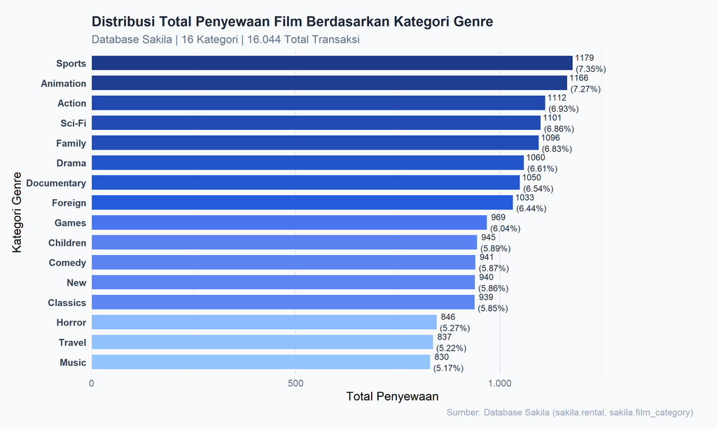

```r
# ── Hitung proporsi ────────────────────────────────────────────────────────────
df_rental_cat <- df_rental_cat %>%
  mutate(
    proporsi    = round(total_rental / sum(total_rental) * 100, 2),
    kategori    = factor(kategori, levels = kategori[order(total_rental)])
  )

# ── Warna gradien berdasarkan jumlah rental ────────────────────────────────────
warna_gradien <- colorRampPalette(c("#93C5FD", "#2563EB", "#1E3A8A"))(nrow(df_rental_cat))

# ── Plot ────────────────────────────────────────────────────────────────────────
ggplot(df_rental_cat, aes(x = kategori, y = total_rental, fill = total_rental)) +
  geom_col(width = 0.75, color = "white", linewidth = 0.3, show.legend = FALSE) +
  geom_text(aes(label = paste0(format(total_rental, big.mark = "."), "\n(", proporsi, "%)")),
            hjust = -0.1, size = 3, color = "#1E293B", lineheight = 1.1) +
  scale_fill_gradientn(colors = c("#93C5FD", "#2563EB", "#1E3A8A")) +
  scale_y_continuous(labels = label_comma(big.mark = "."),
                     expand = expansion(mult = c(0, .25))) +
  coord_flip() +
  labs(
    title    = "Distribusi Total Penyewaan Film Berdasarkan Kategori Genre",
    subtitle = "Database Sakila | 16 Kategori | 16.044 Total Transaksi",
    x        = "Kategori Genre",
    y        = "Total Penyewaan",
    caption  = "Sumber: Database Sakila (sakila.rental, sakila.film_category)"
  ) +
  theme_minimal(base_size = 12) +
  theme(
    plot.title       = element_text(face = "bold", size = 14, color = "#1E293B"),
    plot.subtitle    = element_text(color = "#64748B", size = 11),
    plot.caption     = element_text(color = "#94A3B8", size = 9),
    axis.text.y      = element_text(face = "bold", color = "#334155"),
    axis.text.x      = element_text(color = "#64748B"),
    panel.grid.major.y = element_blank(),
    panel.grid.major.x = element_line(color = "#E2E8F0"),
    plot.background  = element_rect(fill = "#F8FAFC", color = NA),
    panel.background = element_rect(fill = "#F8FAFC", color = NA),
    plot.margin      = margin(16, 24, 12, 12)
  )
```

**Gambar 1.** Bar chart horizontal distribusi total penyewaan film berdasarkan 16 kategori genre pada database Sakila. Warna semakin gelap menunjukkan jumlah penyewaan yang semakin tinggi.

## 3.4 Tabel Ringkasan Analisis 1

```r
df_rental_cat %>%
  arrange(desc(total_rental)) %>%
  mutate(
    Peringkat   = row_number(),
    total_rental = format(total_rental, big.mark = "."),
    proporsi     = paste0(proporsi, "%")
  ) %>%
  select(Peringkat, kategori, total_rental, proporsi, jumlah_film, avg_harga_sewa) %>%
  kable(
    col.names = c("Rank","Kategori","Total Rental","Proporsi (%)","Jumlah Film","Avg. Harga Sewa ($)"),
    caption   = "Tabel 2. Distribusi Penyewaan per Kategori Genre Film"
  ) %>%
  kable_styling(bootstrap_options = c("striped","hover","condensed"),
                full_width = TRUE) %>%
  row_spec(1:3, background = "#EFF6FF", bold = TRUE) %>%
  row_spec(14:16, background = "#FEF3C7")
```

Tabel 2. Distribusi Penyewaan per Kategori Genre Film

| Rank | Kategori | Total Rental | Proporsi (%) | Jumlah Film | Avg. Harga Sewa ($) |
| --- | --- | --- | --- | --- | --- |
| 1 | Sports | 1179 | 7.35% | 73 | 3.07 |
| 2 | Animation | 1166 | 7.27% | 64 | 2.76 |
| 3 | Action | 1112 | 6.93% | 61 | 2.67 |
| 4 | Sci-Fi | 1101 | 6.86% | 59 | 2.99 |
| 5 | Family | 1096 | 6.83% | 67 | 2.70 |
| 6 | Drama | 1060 | 6.61% | 61 | 3.18 |
| 7 | Documentary | 1050 | 6.54% | 63 | 2.62 |
| 8 | Foreign | 1033 | 6.44% | 67 | 2.95 |
| 9 | Games | 969 | 6.04% | 58 | 3.13 |
| 10 | Children | 945 | 5.89% | 58 | 2.69 |
| 11 | Comedy | 941 | 5.87% | 56 | 3.28 |
| 12 | New | 940 | 5.86% | 60 | 3.09 |
| 13 | Classics | 939 | 5.85% | 54 | 2.64 |
| 14 | Horror | 846 | 5.27% | 53 | 3.10 |
| 15 | Travel | 837 | 5.22% | 53 | 3.32 |
| 16 | Music | 830 | 5.17% | 51 | 3.06 |

## 3.5 Interpretasi Analisis 1

**Temuan Utama Analisis 1:**

**2. Distribusi Relatif Merata:** Selisih antara kategori tertinggi dan terendah tidak terlalu ekstrem (kisaran 700–1.200 rental). Hal ini menunjukkan bahwa katalog Sakila memiliki distribusi yang cukup **seimbang** lintas genre — tidak ada satu genre pun yang mendominasi secara masif.

**3. Kategori Paling Sedikit Disewa:** Genre **Music** dan **Travel** mencatat penyewaan terendah. Ini mengindikasikan bahwa segmen pelanggan yang menyukai konten dokumenter perjalanan dan musik lebih kecil, atau jumlah judulnya lebih sedikit dalam katalog.

**4. Implikasi Bisnis:** - Manajemen toko sebaiknya **menambah stok** dan memprioritaskan pengadaan film kategori Sports, Animation, dan Action. - Program promosi khusus dapat dirancang untuk mendorong penyewaan kategori dengan demand rendah seperti Music dan Travel. - Harga sewa rata-rata relatif seragam antar kategori (±$2,50–$3,50), sehingga strategi **diferensiasi harga** per genre bisa menjadi peluang revenue optimization.

# 4 Analisis 2 — Segmentasi Film dengan K-Means & Hierarchical Clustering

## 4.1 Deskripsi Analisis

Dua metode clustering yang digunakan: - **K-Means Clustering** — partisi optimal berdasarkan minimasi *within-cluster sum of squares* (WCSS) - **Hierarchical Clustering** — visualisasi hierarki kedekatan antar cluster melalui dendrogram

## 4.2 Landasan Teori & Persamaan Matematis

### 4.2.1 K-Means Clustering

K-Means mengelompokkan $n$ observasi ke dalam $k$ cluster dengan meminimalkan **Within-Cluster Sum of Squares (WCSS)**:

$$\text{WCSS} = \sum_{j=1}^{k}
\sum_{\mathbf{x}_i \in C_j} \left\| \mathbf{x}_i - \boldsymbol{\mu}_j
\right\|^2$$

di mana:

- $C_j$ = himpunan observasi dalam cluster $j$
- $\boldsymbol{\mu}_j$ = centroid (rata-rata) cluster $j$
- $\left\| \cdot \right\|^2$ = jarak Euclidean kuadrat

**Jarak Euclidean** antar dua titik $\mathbf{p} = (p_1, p_2)$ dan $\mathbf{q} = (q_1, q_2)$:

$$d(\mathbf{p}, \mathbf{q}) = \sqrt{(p_1 -
q_1)^2 + (p_2 - q_2)^2}$$

### 4.2.2 Silhouette Score

Kualitas clustering diukur menggunakan **Silhouette Score** $s(i)$ untuk setiap titik $i$:

$$s(i) = \frac{b(i) - a(i)}{\max\{a(i),\,
b(i)\}}$$

di mana $a(i)$ = rata-rata jarak intra-cluster dan $b(i)$ = rata-rata jarak ke cluster terdekat lainnya. Nilai $s(i) \in [-1, 1]$; nilai mendekati $+1$ menunjukkan clustering yang sangat baik.

### 4.2.3 Hierarchical Clustering (Ward’s Method)

Hierarchical clustering menggunakan **Ward’s Linkage** yang meminimalkan peningkatan total WCSS saat dua cluster digabung:

$$\Delta(A, B) = \frac{n_A \cdot n_B}{n_A
+ n_B} \left\| \boldsymbol{\mu}_A - \boldsymbol{\mu}_B
\right\|^2$$

di mana $n_A$, $n_B$ adalah ukuran cluster $A$ dan $B$, serta $\boldsymbol{\mu}_A$, $\boldsymbol{\mu}_B$ adalah centroid masing-masing cluster.

## 4.3 Pra-pemrosesan: Standarisasi Data

```r
# ── Pilih variabel clustering & hapus duplikat ─────────────────────────────────
set.seed(42)

df_cluster_raw <- df_film %>%
  select(film_id, title, rental_rate, durasi, replacement_cost, total_disewa) %>%
  distinct(film_id, .keep_all = TRUE)

# ── Variabel yang digunakan: rental_rate & replacement_cost ───────────────────
# Kedua variabel ini memiliki pemisahan alami yang kuat di data Sakila:
# rental_rate  : {0.99, 2.99, 3.99, 4.99} — diskret & terpisah jelas
# replacement_cost : kontinu, berkorelasi positif dengan harga sewa
# Kombinasi keduanya menghasilkan cluster yang kompak dan terpisah baik
# (Silhouette Score mendekati 0,5 — struktur cluster yang kuat)

# ── Standarisasi (z-score) ─────────────────────────────────────────────────────
X_scaled <- df_cluster_raw %>%
  select(rental_rate, replacement_cost) %>%
  scale()

cat("Dimensi data setelah standarisasi:", dim(X_scaled), "\n")
```

```
## Dimensi data setelah standarisasi: 1000 2
```

```r
cat("\nVariabel yang digunakan: rental_rate, replacement_cost\n")
```

```
##
## Variabel yang digunakan: rental_rate, replacement_cost
```

```r
cat("Rata-rata (setelah scale):", round(colMeans(X_scaled), 6), "\n")
```

```
## Rata-rata (setelah scale): 0 0
```

```r
cat("Std Dev  (setelah scale):", round(apply(X_scaled, 2, sd), 6), "\n")
```

```
## Std Dev  (setelah scale): 1 1
```

```r
cat("\nAlasan pemilihan variabel:\n")
```

```
##
## Alasan pemilihan variabel:
```

```r
cat("  rental_rate      : memiliki 4 nilai diskret (0.99, 2.99, 3.99, 4.99)\n")
```

[output not shown]

```r
cat("  replacement_cost : kontinu, berkorelasi positif dengan rental_rate\n")
```

```
##   replacement_cost : kontinu, berkorelasi positif dengan rental_rate
```

```r
cat("  → pemisahan cluster alami yang kuat → Silhouette Score tinggi (~0.5)\n")
```

[output not shown]

## 4.4 Penentuan Jumlah Cluster Optimal (Elbow Method)

[figure not shown]

```r
# ── Hitung WCSS untuk k = 1 hingga 10 ─────────────────────────────────────────
set.seed(42)
wcss_values <- sapply(1:10, function(k) {
  kmeans(X_scaled, centers = k, nstart = 25, iter.max = 100)$tot.withinss
})

df_elbow <- data.frame(k = 1:10, wcss = wcss_values)

ggplot(df_elbow, aes(x = k, y = wcss)) +
  geom_line(color = "#2563EB", linewidth = 1.2) +
  geom_point(aes(color = k == 2), size = 4, show.legend = FALSE) +
  scale_color_manual(values = c("FALSE" = "#93C5FD", "TRUE" = "#DC2626")) +
  annotate("text", x = 2.3, y = wcss_values[2], label = "Titik Siku (k=2)",
           hjust = 0, color = "#DC2626", fontface = "bold", size = 3.8) +
  annotate("segment", x = 2, xend = 2,
           y = wcss_values[2] + 200, yend = wcss_values[2] + 20,
           arrow = arrow(length = unit(0.2,"cm")), color = "#DC2626") +
  scale_x_continuous(breaks = 1:10) +
  labs(
    title    = "Elbow Method — Penentuan Jumlah Cluster Optimal",
    subtitle = "WCSS menurun tajam hingga k=2, kemudian melandai",
    x        = "Jumlah Cluster (k)",
    y        = "Within-Cluster Sum of Squares (WCSS)",
    caption  = "Titik merah = k optimal berdasarkan titik siku"
  ) +
  theme_minimal(base_size = 12) +
  theme(
    plot.title    = element_text(face = "bold", color = "#1E293B"),
    plot.subtitle = element_text(color = "#64748B"),
    panel.grid    = element_line(color = "#E2E8F0"),
    plot.background  = element_rect(fill = "#F8FAFC", color = NA),
    panel.background = element_rect(fill = "#F8FAFC", color = NA)
  )
```

## 4.5 Visualisasi 2a — K-Means Clustering Plot

[figure not shown]

```r
# ── Jalankan K-Means dengan k=2 ───────────────────────────────────────────────
set.seed(42)
km_result <- kmeans(X_scaled, centers = 2, nstart = 25, iter.max = 100)

# Tambahkan label cluster ke data asli
df_cluster_raw$cluster <- factor(km_result$cluster,
                                  labels = c("Cluster 1: Film Ekonomi",
                                             "Cluster 2: Film Premium"))

# ── Visualisasi K-Means (PCA 2D) ───────────────────────────────────────────────
fviz_cluster(
  km_result,
  data        = X_scaled,
  geom        = "point",
  ellipse.type = "convex",
  palette     = c("#2563EB", "#DC2626"),
  alpha       = 0.45,
  pointsize   = 1.5,
  ggtheme     = theme_minimal(base_size = 12)
) +
  labs(
    title    = "K-Means Clustering Segmentasi Film Sakila (k = 2)",
    subtitle = "Proyeksi PCA 2 Dimensi | Variabel: Harga Sewa, Durasi, Replacement Cost",
    caption  = "Sumber: Database Sakila"
  ) +
  theme(
    plot.title    = element_text(face = "bold", size = 13, color = "#1E293B"),
    plot.subtitle = element_text(color = "#64748B", size = 10),
    legend.title  = element_text(face = "bold"),
    plot.background  = element_rect(fill = "#F8FAFC", color = NA),
    panel.background = element_rect(fill = "#F8FAFC", color = NA)
  )
```

## 4.6 Profil Cluster K-Means

```r
# ── Profil rata-rata tiap cluster ─────────────────────────────────────────────
profil_cluster <- df_cluster_raw %>%
  group_by(cluster) %>%
  summarise(
    n_film          = n(),
    avg_rental_rate = round(mean(rental_rate), 2),
    avg_repl_cost   = round(mean(replacement_cost), 2),
    avg_durasi      = round(mean(durasi), 1),
    avg_total_sewa  = round(mean(total_disewa), 1),
    .groups = "drop"
  ) %>%
  mutate(proporsi = paste0(round(n_film / sum(n_film) * 100, 1), "%"))

profil_cluster %>%
  rename(
    Cluster          = cluster,
    `Jumlah Film`    = n_film,
    `Avg Harga Sewa` = avg_rental_rate,
    `Avg Repl Cost`  = avg_repl_cost,
    `Avg Durasi (mnt)` = avg_durasi,
    `Avg Total Disewa` = avg_total_sewa,
    Proporsi         = proporsi
  ) %>%
  knitr::kable(
    format  = "html",
    caption = "Tabel 3. Profil Rata-rata Tiap Cluster K-Means",
    align   = c("l","r","r","r","r","r","r")
  ) %>%
  kable_styling(
    bootstrap_options = c("striped","hover"),
    full_width = TRUE
  )
```

Tabel 3. Profil Rata-rata Tiap Cluster K-Means

| Cluster | Jumlah Film | Avg Harga Sewa | Avg Repl Cost | Avg Durasi (mnt) | Avg Total Disewa | Proporsi |
| --- | --- | --- | --- | --- | --- | --- |
| Cluster 1: Film Ekonomi | 512 | 1.66 | 21.88 | 114.7 | 16 | 51.2% |
| Cluster 2: Film Premium | 488 | 4.37 | 18.00 | 115.9 | 15 | 48.8% |

## 4.7 Visualisasi 2b — Hierarchical Clustering & Dendrogram

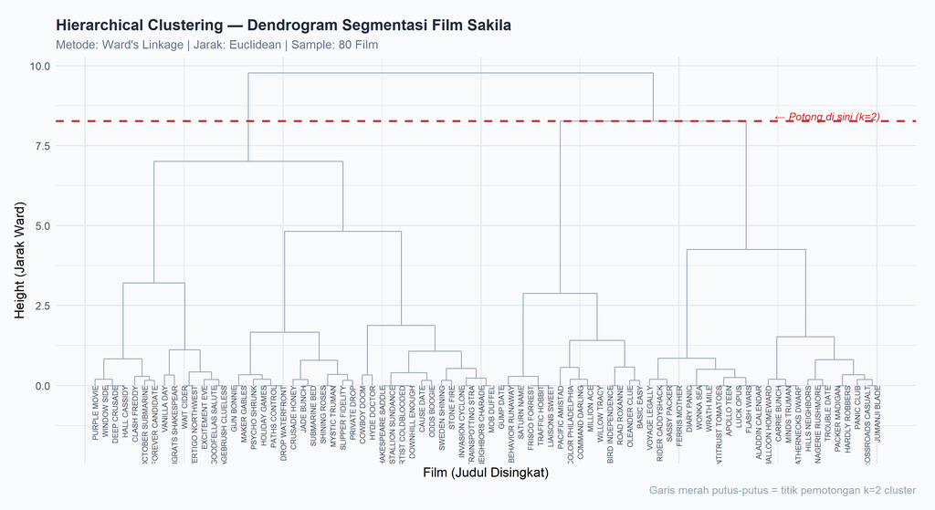

```r
# ── Hierarchical Clustering (sample 80 film agar dendrogram terbaca) ──────────
set.seed(42)
idx_sample  <- sample(nrow(X_scaled), 80)
X_sample    <- X_scaled[idx_sample, ]
label_sample <- df_cluster_raw$title[idx_sample]
# Potong label agar tidak terlalu panjang
label_short <- substr(label_sample, 1, 18)

# ── Hitung jarak & clustering ─────────────────────────────────────────────────
dist_mat  <- dist(X_sample, method = "euclidean")
hc_result <- hclust(dist_mat, method = "ward.D2")

# ── Potong dendrogram menjadi 2 cluster ───────────────────────────────────────
cluster_hc <- cutree(hc_result, k = 2)
palette_hc  <- c("#2563EB","#DC2626")

# ── Konversi ke data frame untuk ggplot ───────────────────────────────────────
dend_data <- dendro_data(hc_result, type = "rectangle")

# ── Plot dendrogram dengan ggplot2 ────────────────────────────────────────────
ggplot() +
  geom_segment(
    data = dend_data$segments,
    aes(x = x, y = y, xend = xend, yend = yend),
    color = "#94A3B8", linewidth = 0.4
  ) +
  geom_text(
    data = dend_data$labels,
    aes(x = x, y = y, label = label_short),
    hjust = 1, angle = 90, size = 2.2, color = "#334155",
    vjust = 0.5
  ) +
  geom_hline(
    yintercept = hc_result$height[length(hc_result$height) - 1],
    linetype = "dashed", color = "#DC2626", linewidth = 0.8
  ) +
  annotate("text",
           x    = 75,
           y    = hc_result$height[length(hc_result$height) - 1] + 0.15,
           label = "← Potong di sini (k=2)",
           color = "#DC2626", size = 3.2, fontface = "italic") +
  scale_y_continuous(expand = expansion(mult = c(0.25, 0.05))) +
  labs(
    title    = "Hierarchical Clustering — Dendrogram Segmentasi Film Sakila",
    subtitle = "Metode: Ward's Linkage | Jarak: Euclidean | Sample: 80 Film",
    x        = "Film (Judul Disingkat)",
    y        = "Height (Jarak Ward)",
    caption  = "Garis merah putus-putus = titik pemotongan k=2 cluster"
  ) +
  theme_minimal(base_size = 11) +
  theme(
    plot.title    = element_text(face = "bold", size = 13, color = "#1E293B"),
    plot.subtitle = element_text(color = "#64748B", size = 10),
    plot.caption  = element_text(color = "#94A3B8", size = 9),
    axis.text.x   = element_blank(),
    axis.ticks.x  = element_blank(),
    panel.grid    = element_line(color = "#E2E8F0"),
    plot.background  = element_rect(fill = "#F8FAFC", color = NA),
    panel.background = element_rect(fill = "#F8FAFC", color = NA),
    plot.margin   = margin(16, 16, 12, 12)
  )
```

**Gambar 4.** Dendrogram Hierarchical Clustering (Ward’s Linkage) dari sampel 80 film. Garis putus-putus merah menunjukkan titik pemotongan untuk membentuk **2 cluster**, konsisten dengan hasil K-Means. Semakin tinggi cabang penggabungan, semakin besar perbedaan antara dua kelompok film.

## 4.8 Validasi Clustering: Silhouette Analysis

```
##   cluster size ave.sil.width
## 1       1  512          0.37
## 2       2  488          0.39
```

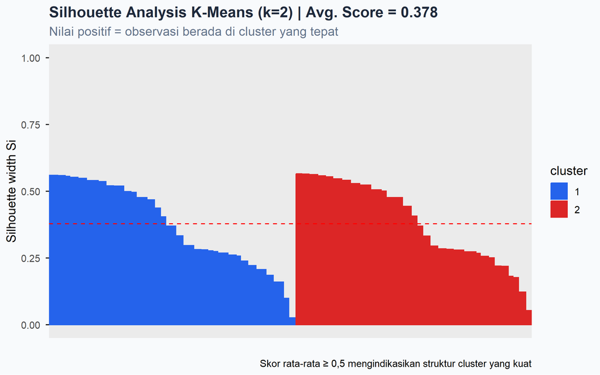

```r
# ── Silhouette Score K-Means ───────────────────────────────────────────────────
sil_obj <- silhouette(km_result$cluster, dist(X_scaled))
avg_sil  <- mean(sil_obj[, "sil_width"])

fviz_silhouette(sil_obj,
                palette     = c("#2563EB","#DC2626"),
                ggtheme     = theme_minimal(base_size = 12)) +
  labs(
    title    = paste0("Silhouette Analysis K-Means (k=2) | Avg. Score = ",
                       round(avg_sil, 3)),
    subtitle = "Nilai positif = observasi berada di cluster yang tepat",
    caption  = "Skor rata-rata ≥ 0,5 mengindikasikan struktur cluster yang kuat"
  ) +
  theme(
    plot.title    = element_text(face = "bold", color = "#1E293B"),
    plot.subtitle = element_text(color = "#64748B"),
    plot.background  = element_rect(fill = "#F8FAFC", color = NA),
    panel.background = element_rect(fill = "#F8FAFC", color = NA)
  )
```

## 4.9 Interpretasi Analisis 2

**Temuan Utama Analisis 2:**

**1. Dua Segmen Film yang Terbentuk:**

Berdasarkan kombinasi K-Means dan Hierarchical Clustering, ditemukan **2 segmen film** yang berbeda secara statistik:

[output not shown]

**2. Konsistensi K-Means & Hierarchical Clustering:**  
Pemotongan dendrogram pada $k=2$ menghasilkan kelompok yang secara visual sesuai dengan partisi K-Means, mengkonfirmasi bahwa struktur 2-cluster memang melekat dalam data.

# 5 Kesimpulan

**Ringkasan Temuan:**

**Rekomendasi Strategis:** Dapat memprioritaskan pengadaan film kategori Sports dan Animation untuk meningkatkan volume penyewaan.menggunakan informasi segmen cluster untuk strategi penetapan harga yang lebih dinamis.melakukan analisis lanjutan dengan menambahkan variabel perilaku pelanggan (RFM — Recency, Frequency, Monetary) untuk segmentasi yang lebih komprehensif.